# Analysis of 2018 bootcamp survey

Rick Gilmore

2018-08-14 14:50:34

## Goals

- Download and clean data from 2018 R Bootcamp Survey
- Visualize data
- Prepare reports in `ioslides_presentation`, `pdf_document`, and `word_document` formats

## Preliminaries

Load required packages.

```r
library(tidyverse)
library(googlesheets)
```

## Load data and examine

The survey data are stored in a [Google Sheet](https://docs.google.com/spreadsheets/d/1-YB0iWUNN_9oxBhz221NFiyBOcwMfHziFeUiUvQwn7k/edit#gid=2108979913). We’ll use the `googlesheets` package to open it and create a data frame. Documentation about the package can be found [here](https://cran.r-project.org/web/packages/googlesheets/vignettes/basic-usage.html).

There are some idiosyncrasies in using the `googlesheets` package in an R Markdown document because it requires interaction with the console, so I created a separate R script, `Get_bootcamp_googlesheet.R` to extract the survey data. If you try to execute the next chunk, it may give you an error, or it may ask you to allow `googlesheets` to access information in your Google profile.

```
survey_url <- "https://docs.google.com/spreadsheets/d/1-YB0iWUNN_9oxBhz221NFiyBOcwMfHziFeUiUvQwn7k/edit?usp=sharing"

bootcamp_by_url <- survey_url %>%
  extract_key_from_url() %>%
  gs_key()

bootcamp_sheets <- gs_ws_ls(bootcamp_by_url)

boot_data <- bootcamp_by_url %>%
  gs_read(bootcamp_sheets[1])

write_csv(boot_data, path=params$data_file_out)
```

This script downloads the data file saves it to a CSV under ../data/survey_2018.csv. We can then load this file.

I also created a test data file, `data/survey-test.csv` so I could see how everything worked before y’all filled out your responses. The `R/Make_test_survey.R` file shows how I did this. It’s a great, reproducible practice to **simulate the data you expect**, then run it through your pipeline.

```r
# Created test data set for testing.
survey <- read_csv(params$data_file_in)
# Or choose data from respondents
#survey <- read_csv(data_file_in)
```

```r
survey
```

| Timestamp | R_exp | Banjo | Psych_age_yrs | Sleep_hrs | Fav_date | Crisis |
| --- | --- | --- | --- | --- | --- | --- |
| 2018-07-24 14:54:13 | limited | 4 | 74 | 6.972678 | 2018-07-24 | Yes, significant |
| 2018-07-24 14:54:13 | some | 8 | 27 | 7.744763 | 2018-07-24 | Yes, slight |
| 2018-07-24 14:54:13 | none | 3 | 26 | 6.810988 | 2018-07-24 | Yes, slight |
| 2018-07-24 14:54:13 | limited | 8 | 80 | 6.214324 | 2018-07-24 | Yes, significant |
| 2018-07-24 14:54:13 | none | 7 | 17 | 7.732838 | 2018-07-24 | Yes, significant |
| 2018-07-24 14:54:13 | some | 10 | 37 | 8.726117 | 2018-07-24 | Yes, significant |
| 2018-07-24 14:54:13 | limited | 10 | 46 | 6.674285 | 2018-07-24 | Yes, slight |
| 2018-07-24 14:54:13 | lots | 2 | 32 | 8.339286 | 2018-07-24 | No |
| 2018-07-24 14:54:13 | lots | 3 | 55 | 7.708710 | 2018-07-24 | No |
| 2018-07-24 14:54:13 | lots | 10 | 55 | 8.572957 | 2018-07-24 | No |

[output cut: 40 more lines]

The `str()` or ‘structure’ command is also a great way to see what you’ve got.

```r
str(survey)
```

```
Classes ‘tbl_df’, ‘tbl’ and 'data.frame':   50 obs. of  7 variables:
 $ Timestamp    : POSIXct, format: "2018-07-24 14:54:13" ...
 $ R_exp        : chr  "limited" "some" "none" "limited" ...
 $ Banjo        : int  4 8 3 8 7 10 10 2 3 10 ...
 $ Psych_age_yrs: int  74 27 26 80 17 37 46 32 55 55 ...
 $ Sleep_hrs    : num  6.97 7.74 6.81 6.21 7.73 ...
 $ Fav_date     : Date, format: "2018-07-24" ...
 $ Crisis       : chr  "Yes, significant" "Yes, slight" "Yes, slight" "Yes, significant" ...
 - attr(*, "spec")=List of 2
  ..$ cols   :List of 7
  .. ..$ Timestamp    :List of 1
  .. .. ..$ format: chr ""
  .. .. ..- attr(*, "class")= chr  "collector_datetime" "collector"
  .. ..$ R_exp        : list()
  .. .. ..- attr(*, "class")= chr  "collector_character" "collector"
  .. ..$ Banjo        : list()
  .. .. ..- attr(*, "class")= chr  "collector_integer" "collector"
  .. ..$ Psych_age_yrs: list()
  .. .. ..- attr(*, "class")= chr  "collector_integer" "collector"
  .. ..$ Sleep_hrs    : list()
  .. .. ..- attr(*, "class")= chr  "collector_double" "collector"
  .. ..$ Fav_date     :List of 1
  .. .. ..$ format: chr ""
  .. .. ..- attr(*, "class")= chr  "collector_date" "collector"
  .. ..$ Crisis       : list()
  .. .. ..- attr(*, "class")= chr  "collector_character" "collector"
  ..$ default: list()
  .. ..- attr(*, "class")= chr  "collector_guess" "collector"
  ..- attr(*, "class")= chr "col_spec"
```

Clearly, we need to do some cleaning before we can do anything with this.

Let’s start by renaming variables.

```r
names(survey) <- c("Timestamp",
                  "R_exp",
                  "Banjo",
                  "Psych_age_yrs",
                  "Sleep_hrs",
                  "Fav_day",
                  "Crisis")
```

```r
# complete.cases() drops NAs
survey <- survey[complete.cases(survey),]
survey
```

| Timestamp | R_exp | Banjo | Psych_age_yrs | Sleep_hrs | Fav_day | Crisis |
| --- | --- | --- | --- | --- | --- | --- |
| 2018-07-24 14:54:13 | limited | 4 | 74 | 6.972678 | 2018-07-24 | Yes, significant |
| 2018-07-24 14:54:13 | some | 8 | 27 | 7.744763 | 2018-07-24 | Yes, slight |
| 2018-07-24 14:54:13 | none | 3 | 26 | 6.810988 | 2018-07-24 | Yes, slight |
| 2018-07-24 14:54:13 | limited | 8 | 80 | 6.214324 | 2018-07-24 | Yes, significant |
| 2018-07-24 14:54:13 | none | 7 | 17 | 7.732838 | 2018-07-24 | Yes, significant |
| 2018-07-24 14:54:13 | some | 10 | 37 | 8.726117 | 2018-07-24 | Yes, significant |
| 2018-07-24 14:54:13 | limited | 10 | 46 | 6.674285 | 2018-07-24 | Yes, slight |
| 2018-07-24 14:54:13 | lots | 2 | 32 | 8.339286 | 2018-07-24 | No |
| 2018-07-24 14:54:13 | lots | 3 | 55 | 7.708710 | 2018-07-24 | No |
| 2018-07-24 14:54:13 | lots | 10 | 55 | 8.572957 | 2018-07-24 | No |

[output cut: 40 more lines]

Now, lets make sure we have numbers where we expect them.

```r
survey$Sleep_hrs <- readr::parse_number(survey$Sleep_hrs)
survey
```

| Timestamp | R_exp | Banjo | Psych_age_yrs | Sleep_hrs | Fav_day | Crisis |
| --- | --- | --- | --- | --- | --- | --- |
| 2018-07-24 14:54:13 | limited | 4 | 74 | 6.972678 | 2018-07-24 | Yes, significant |
| 2018-07-24 14:54:13 | some | 8 | 27 | 7.744763 | 2018-07-24 | Yes, slight |
| 2018-07-24 14:54:13 | none | 3 | 26 | 6.810988 | 2018-07-24 | Yes, slight |
| 2018-07-24 14:54:13 | limited | 8 | 80 | 6.214324 | 2018-07-24 | Yes, significant |
| 2018-07-24 14:54:13 | none | 7 | 17 | 7.732838 | 2018-07-24 | Yes, significant |
| 2018-07-24 14:54:13 | some | 10 | 37 | 8.726117 | 2018-07-24 | Yes, significant |
| 2018-07-24 14:54:13 | limited | 10 | 46 | 6.674285 | 2018-07-24 | Yes, slight |
| 2018-07-24 14:54:13 | lots | 2 | 32 | 8.339286 | 2018-07-24 | No |
| 2018-07-24 14:54:13 | lots | 3 | 55 | 7.708710 | 2018-07-24 | No |
| 2018-07-24 14:54:13 | lots | 10 | 55 | 8.572957 | 2018-07-24 | No |

[output cut: 40 more lines]

Looks good. Let’s save that cleaned file so we don’t have to do this again.

```r
write_csv(survey, path="../data/survey_clean.csv")
```

We may want to make the `R_exp` variable ordered.

```r
(survey_responses <- unique(survey$R_exp))
```

```
[1] "limited" "some"    "none"    "lots"    "pro"
```

This shows us the different survey response values.

```r
survey$R_exp <- ordered(survey$R_exp, levels=c("none",
                                               "limited",
                                               "some",
                                               "lots",
                                               "pro"))
```

## Visualization

Now, we follow Mike Meyer’s advice: “Plot your data!”

### Descriptive plots

```r
R_exp_hist <- survey %>%
  ggplot() +
  aes(x=R_exp) +
  geom_histogram(stat = "count") # R_exp is discrete
```

```
Ignoring unknown parameters: binwidth, bins, pad
```

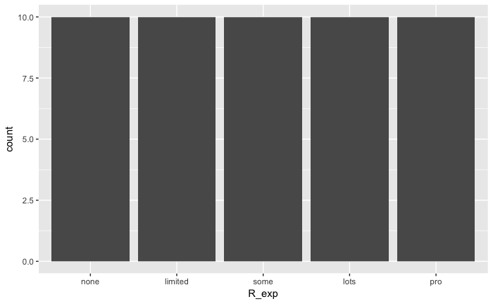

```r
R_exp_hist
```

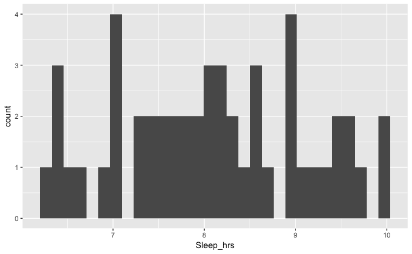

```r
Sleep_hrs_hist <- survey %>%
  ggplot() +
  aes(x=Sleep_hrs) +
  geom_histogram() # Sleep_hrs is continuous
Sleep_hrs_hist
```

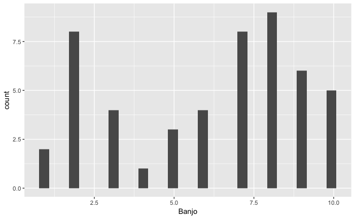

```r
Banjo_hist <- survey %>%
  ggplot() +
  aes(x=Banjo) +
  geom_histogram()
Banjo_hist
```

Does R experience have any relation to banjo music enthusiasm?

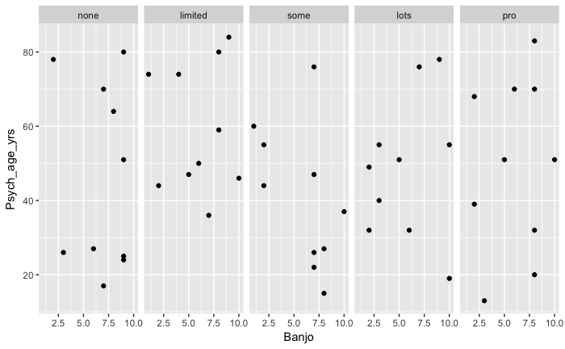

```r
Banjo_vs_r_exp <- survey %>%
  ggplot() +
  aes(x=Banjo, y=Psych_age_yrs) +
  facet_grid(. ~ R_exp) +
  geom_point()
  # + stat_smooth()
Banjo_vs_r_exp
```

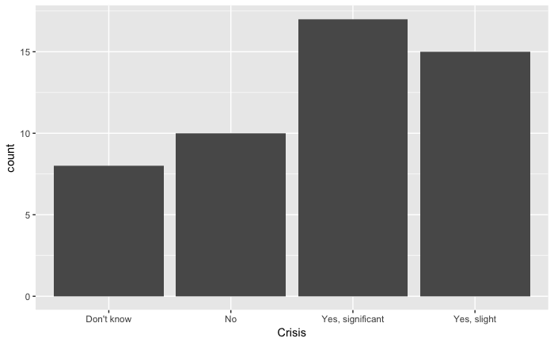

```r
crisis_hist <- survey %>%
  ggplot() +
  aes(x=Crisis) +
#  geom_histogram(stat = "count") +
  geom_bar()
crisis_hist
```

## Data documentation (codebook)

Every data set should be documented. You can generate a template data codebook with some useful summary information using the package `dataMaid`.

```r
if(!require(dataMaid)){install.packages('dataMaid')}
library(dataMaid)
dataMaid::makeCodebook(data = survey,
                       reportTitle = 'Codebook for 2018 R bootcamp survey',
                       replace = TRUE)
```

Then, we can look at the `codebook_survey.Rmd` file and edit it as needed, especially the section with the code descriptions.

```
# Codebook summary table

------------------------------------------------------------------------------
Label   Variable                Class         # unique  Missing  Description
                                                values
------- ----------------------- ----------- ---------- --------- -------------
        **[Timestamp]**         POSIXct              1  0.00 %   Time & date survey was completed

        **[R\_exp]**            ordered              5  0.00 %   Levels of R experience: {none", "limited", "some", "lots","pro")}

        **[Banjo]**             integer             10  0.00 %   Level of enthusiasm for banjo music [1,10]

        **[Psych\_age\_yrs]**   integer             33  0.00 %   Age participant reports feeling

        **[Sleep\_hrs]**        numeric             50  0.00 %   Preferred number of hours/day spent sleeping

        **[Fav\_day]**          Date                 1  0.00 %   Favorite day of the week: {'Mon', 'Tue', 'Wed', 'Thu', 'Fri', 'Sat', 'Sun'}

        **[Crisis]**            character            4  0.00 %   Is there a 'reproducibility' crisis in psychology: {'Yes, a significant crisis', 'Yes, a slight crisis', 'No', 'Don't know'}
------------------------------------------------------------------------------
```

## Analysis

I could use a document like this to plan out my analysis plan **before** I conduct it. If I used simulated data, I could make sure that my workflow will run when I get real (cleaned) data. I could even preregister my analysis plan before I conduct it. That doesn’t preclude later exploratory analyses, but it does hold me and my collaborators accountable for what I predicted in advance.

## Notes

Notice that I sometimes put a label like `Banjo-vs-r-exp` in the brackets `{}`for a given ‘chunk’ of R code. The main reasons to do this are:

- It sometimes makes it easier to debug your code.
- In some cases, you can have this ‘chunk’ name serve as the file name for a figure you generate within a chunk.
- In a bit, we’ll see how these chunk names are useful for making tables, figures, and equations that generate their own numbers.